# Housing Price vs. Supply 2024

### Scatterplot of Months’ Supply and Median Price

We also visualized this comparison with a scatterplot of all 50 states and D.C. Looking at the scatterplot results, the positive association between median sale price and months’ supply is plainly visible.

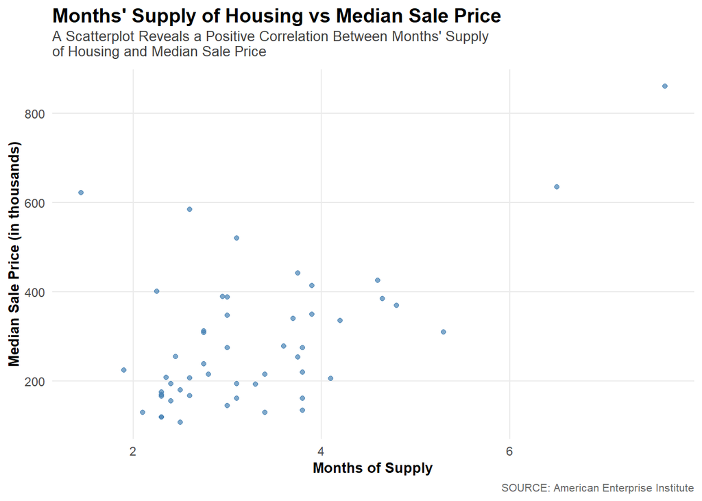

```r
#this chunk contains the all states unfactored scatter
#compare color scale w/ ..._all df

#now actual plot
allstatescatterplot <- ggplot(housing_2024_all_plot, aes(x = Months_Supply, y = Median_Sale_Price_in_k)) +
  geom_point(color="steelblue", alpha = 0.7) +
  # geom_smooth(method = "lm", se = FALSE, color = "black") +
  labs(
    title = "Months' Supply of Housing vs Median Sale Price",
    subtitle= "A Scatterplot Reveals a Positive Correlation Between Months' Supply\nof Housing and Median Sale Price",
    x = "Months of Supply",
    y = "Median Sale Price (in thousands)",
    caption = "SOURCE: American Enterprise Institute") +
  theme_minimal()+
  theme(plot.title = element_text(face = "bold",
                                  size = 14,
                                  margin = margin(b = 3)),
        plot.subtitle = element_text(size = 10,
                                     color = "gray25",
                                     margin = margin(b = 8)),
        axis.title = element_text(size = 10,
                                  face = "bold"),
        axis.text = element_text(size = 9),
        plot.caption = element_text(size = 8,
                                    color = "gray40",
                                    hjust = 1),
        panel.grid.minor = element_blank(),
        panel.background = element_blank(),
        plot.background = element_blank())

# ggsave("housing_supply_vs_price_allstates.png", plot = allstatescatterplot, width = 10, height = 6, dpi = 300)

allstatescatterplot
```

```r
#hist plotting with df ..._all
#housing_price_hist <- ggplot(housing_2024_all, aes(x = Median_Sale_Price_in_k)) +
#  geom_histogram(binwidth = 25, fill = "skyblue", color = "black") +
#  scale_x_continuous(labels = scales::dollar_format(prefix = "$", suffix = "k")) +
#  labs(
#    title = "Distribution of Median Sale Prices",
#    subtitle = "Most U.S. counties cluster below $300k, with a long right-skewed tail #in higher-priced markets",
#    x = "Median Sale Price (in thousands)",
#    y = "Number of Counties",
#    caption = "SOURCE: American Enterprise Institute") +
#  theme_minimal() +
#  theme(plot.title = element_text(face = "bold",
#                                  size = 14,
#                                  margin = margin(b = 3)),
#        plot.subtitle = element_text(size = 10,
#                                     color = "gray25",
#                                     margin = margin(b = 8)),
#        axis.title = element_text(size = 10,
#                                  face = "bold"),
#        axis.text = element_text(size = 9),
#        plot.caption = element_text(size = 8,
#                                    color = "gray40",
#                                    hjust = 1),
#        panel.grid.minor = element_blank(),
#        panel.background = element_blank(),
#        plot.background = element_blank()) #

#ggsaving
#ggsave(plot = housing_price_hist,
#       filename = "housing_price_hist.png",
#       width = 7,
#       height = 4,
#       dpi = 500,
#       bg = "transparent")
#
#needs a subtitle with commentary, just remembered all need a caption with the source named, and we can prob add other elements to this, because otherwise it seems to obvi to me
```

We also wanted to separate out our subsetted data and overlay it onto the map above. In the following scatterplot, we see a striking trend revealed from the overlays of the subsetted scatter plots onto the 50 states and D.C. scatterplot. The association between months’ supply and median sale price is glaringly obvious in this graph.

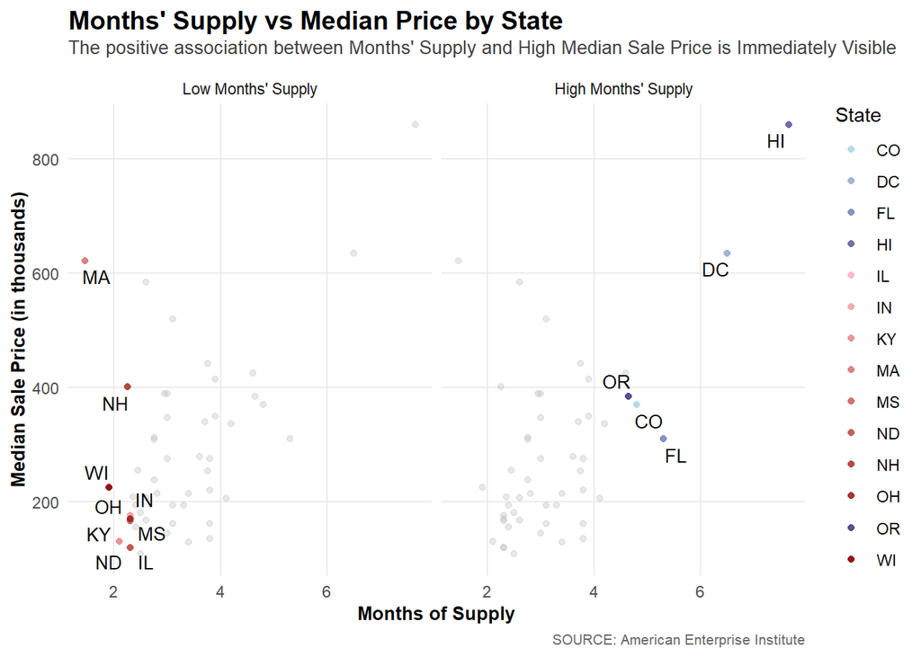

```r
#all in gray with faceted compare in color with states labeled ####
tierhighlightscatterplot <- ggplot() +
  geom_point(data = housing_2024_all_plot, aes(x = Months_Supply, y = Median_Sale_Price_in_k),
             color = "gray70", alpha = 0.3, size = 1.5) +
  geom_point(data = housing_compare_all_plot,
             aes(x = Months_Supply, y = Median_Sale_Price_in_k, color = State),
             size = 1.5, alpha = 0.9) +
  geom_text_repel(data = label_points_all,
                  aes(x = Months_Supply, y = Median_Sale_Price_in_k,
                      label = State),
                  size = 3.5, color= "black", stroke=0.01, segment.color = NA, segment.size = 0.3,
                  segment.alpha = 1, min.segment.length = 0, show.legend = FALSE) +
  facet_wrap(~ StateGroup) +
  scale_color_manual(values = state_colors_all) +
  labs(
    title = "Months' Supply vs Median Price by State",
    subtitle = "The positive association between Months' Supply and High Median Sale Price is Immediately Visible",
    x = "Months of Supply",
    y = "Median Sale Price (in thousands)",
    color = "State",
    caption = "SOURCE: American Enterprise Institute") +
  theme_minimal()+
  theme(plot.title = element_text(face = "bold",
                                  size = 14,
                                  margin = margin(b = 3)),
        plot.subtitle = element_text(size = 10,
                                     color = "gray25",
                                     margin = margin(b = 8)),
        axis.title = element_text(size = 10,
                                  face = "bold"),
        axis.text = element_text(size = 9),
        plot.caption = element_text(size = 8,
                                    color = "gray40",
                                    hjust = 1),
        panel.grid.minor = element_blank(),
        panel.background = element_blank(),
        plot.background = element_blank())

# ggsave("housing_supply_vs_price_tierhighlight.png", plot = tierhighlightscatterplot, width = 10, height = 6, dpi = 300)

tierhighlightscatterplot
```

```r
#both together in gray with compare in color with states labeled w/ ..._all df
#ggplot() +
#  geom_point(data = housing_2024_all,
#             aes(x = Months_Supply, y = Median_Sale_Price_in_k),
#             color = "gray70", alpha = 0.3, size = 1) +
  # geom_path(data = housing_compare %>% filter(StateGroup == "States with the Most Houses"),
  #           aes(x = Months_Supply, y = Median_Sale_Price_in_k, group = State, color = State),
  #           alpha = 0.8, size = 1) +
#  geom_point(data = housing_compare_all %>% filter(StateGroup == "States with the Most Houses"),
#             aes(x = Months_Supply, y = Median_Sale_Price_in_k, color = State),
#             alpha = 0.5, size = 2) +
#  # geom_path(data = housing_compare %>% filter(StateGroup == "States with the Fewest Houses"),
  #           aes(x = Months_Supply, y = Median_Sale_Price_in_k, group = State, color = State),
  #           alpha = 0.8, size = 1) +
 # geom_point(data = housing_compare_all %>% filter(StateGroup == "States with the Fewest Houses"),
 #            aes(x = Months_Supply, y = Median_Sale_Price_in_k, color = State),
#             alpha = 0.5, size = 2) +
#  scale_color_manual(values = state_colors_all) +
#  labs(
 #   title = "Housing Supply vs Median Price: All Counties with Highlights",
#    subtitle = "Gray points: All counties | Blue shades: States with Most Houses | Red shades: States with Fewest Houses",
#    x = "Months of Supply",
 #   y = "Median Sale Price (in thousands)",
  #  color = "State",
#    caption = "SOURCE: American Enterprise Institute") +
#  theme_minimal()
```

```r
#housing_constr_all = housing_2024_all
#housing_constr_all = housing_constr_all %>%
#  mutate(constr_bins = cut(New_Constr_by_share_of_sales_percent, breaks=10))

#ggplot(housing_constr_all, aes(x = constr_bins, y = Median_Sale_Price_in_k, fill=constr_bins)) +
#  geom_boxplot() +
 # labs(
#    title = "Median Sale Price by Percent New Construction (2024)",
#    x = "New Construction by Share of Sales Percent",
#    y = "Median Sale Price (in thousands)",
#    caption = "SOURCE: American Enterprise Institute") +
#  theme_minimal()

# Perhaps new construction indicates high demand, and as such, the more new construction, the higher the median sale price?
#I would like to know which states fall into these buckets. In which states are the top quarter and bottom quarter? BW
#I'm going to break this into smaller buckets and investigate.BW
```

In this final visualization, we overlayed the median sale price, represented by black dots, with the monetary values along the top x axis onto the county distributions of months supply on the bottom x axis across the states in our subsetted dataset.

There is a clear trend in higher months’ supply correlating with higher median sale price. We also see a few states where outliers skew the median sale price- this is most obvious for Massachusetts and New Hampshire.

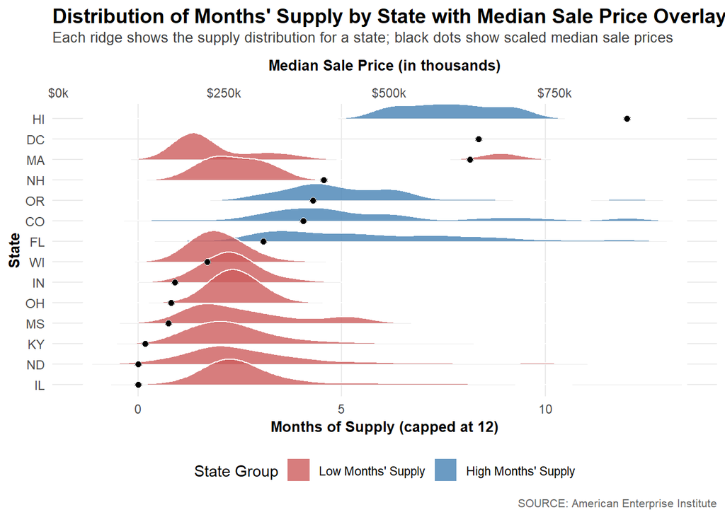

```r
#housing supply dist w 12 states for context, all df

#prep
max_months <- 12
housing_ridge <- housing_compare_all %>%
  mutate(Months_Supply_Capped = pmin(Months_Supply, max_months))

#medians per state
state_medians <- housing_ridge %>%
  group_by(State) %>%
  summarize(
    Median_Sale_Price = median(Median_Sale_Price_in_k, na.rm = TRUE),
    .groups = "drop"
  )

#normalize sale price to match the x-axis range (e.g. 0–12 months)
sale_price_min <- min(state_medians$Median_Sale_Price, na.rm = TRUE)
sale_price_max <- max(state_medians$Median_Sale_Price, na.rm = TRUE)

#normalize price into 0-12 scale
scale_price_to_months <- function(price_k) {
  scales::rescale(price_k, to = c(0, max_months), from = c(sale_price_min, sale_price_max))
}

#apply scaled value
state_medians <- state_medians %>%
  mutate(Scaled_Sale_Price = scale_price_to_months(Median_Sale_Price))

#reorder
state_order <- state_medians %>%
  arrange(Median_Sale_Price) %>%
  pull(State)
housing_ridge <- housing_ridge %>%
  mutate(State = factor(State, levels = state_order))

#save plot as object
supplyridge_12medianprice_plot <- ggplot(housing_ridge, aes(x = Months_Supply_Capped, y = State, fill = StateGroup), fill = StateGroup) +
  geom_density_ridges(scale = 1.5, alpha = 0.8, color = "white") +
  geom_point(data = state_medians,
             aes(x = Scaled_Sale_Price, y = State),
             inherit.aes = FALSE,
             shape = 21, fill = "black", color = "white", size = 2) +
  scale_fill_manual(values = c("Low Months' Supply" = "indianred", "High Months' Supply" = "steelblue")) +
  scale_x_continuous(
    name = "Months of Supply (capped at 12)",
    sec.axis = sec_axis(
      trans = ~ scales::rescale(., to = c(sale_price_min, sale_price_max), from = c(0, max_months)),
      name = "Median Sale Price (in thousands)",
      labels = dollar_format(prefix = "$", suffix = "k"))) +
  labs(
    title = "Distribution of Months' Supply by State with Median Sale Price Overlay",
    subtitle = "Each ridge shows the supply distribution for a state; black dots show scaled median sale prices",
    y = "State",
    fill = "State Group",
    caption = "SOURCE: American Enterprise Institute") +
  theme_minimal() +
  theme(
    legend.position = "bottom",
    axis.title.x.top = element_text(margin = margin(b = 10)))+
  theme(plot.title = element_text(face = "bold",
                                  size = 14,
                                  margin = margin(b = 3)),
        plot.subtitle = element_text(size = 10,
                                     color = "gray25",
                                     margin = margin(b = 8)),
        axis.title = element_text(size = 10,
                                  face = "bold"),
        axis.text = element_text(size = 9),
        plot.caption = element_text(size = 8,
                                    color = "gray40",
                                    hjust = 1),
        panel.grid.minor = element_blank(),
        panel.background = element_blank(),
        plot.background = element_blank())

# ggsave("supply_ridge_12_saleprice_plot.png", plot = supplyridge_12medianprice_plot, width = 10, height = 6, dpi = 300)

supplyridge_12medianprice_plot
```

## Significance Testing

Though the graphs have proven quite conclusive, we proceed with ANOVA testing to confirm the existence of and nature of the relationship between our variables.

$H_0: \mu_{AK} = \mu_{AL} = ... = \mu_{WY}$

$H_1:$ At least one $\mu$ is different

```r
states_median_sale_price_anova = aov(Median_Sale_Price_in_k ~ State, data = housing_2024_all)
xkabledply(states_median_sale_price_anova, title = "ANOVA result summary")
```

ANOVA result summary

|  | Df | Sum Sq | Mean Sq | F value | Pr(>F) |
| --- | --- | --- | --- | --- | --- |
| State | 50 | 2.9e+07 | 580680 | 34.9 | 0 |
| Residuals | 2703 | 4.5e+07 | 16638 | NA | NA |

Median sale price varies highly significantly by state, with a p-value smaller than r can store. As such, we reject the null hypothesis, concluding that it is improbable that states have the same true median sale price.

### Post-hoc Tukey HSD

```r
states_median_sale_price_tukey <- TukeyHSD(states_median_sale_price_anova)
states_median_sale_price_tukey$State[, "p adj"] %>%
  subset(states_median_sale_price_tukey$State[, "p adj"] < 0.05)
```

```
##    AL-AK    AR-AK    CA-AK    GA-AK    HI-AK    IA-AK    IL-AK    IN-AK
## 1.54e-03 1.08e-07 6.25e-04 6.35e-03 1.46e-05 3.46e-06 6.24e-07 1.93e-04
##    KY-AK    LA-AK    MA-AK    MI-AK    MN-AK    MO-AK    MS-AK    ND-AK
## 1.31e-07 6.85e-05 1.27e-07 4.45e-04 1.77e-02 1.19e-03 6.56e-04 3.64e-06
##    NE-AK    OH-AK    OK-AK    PA-AK    TN-AK    TX-AK    WV-AK    CA-AL
## 1.56e-06 2.14e-04 3.92e-07 2.02e-03 2.19e-02 7.05e-03 2.49e-08 0.00e+00
##    CO-AL    FL-AL    HI-AL    ID-AL    MA-AL    MD-AL    MT-AL    NH-AL
## 0.00e+00 6.66e-03 0.00e+00 2.01e-06 0.00e+00 2.95e-05 3.20e-05 2.19e-02
##    NJ-AL    OR-AL    RI-AL    UT-AL    VA-AL    WA-AL    AZ-AR    CA-AR
## 0.00e+00 1.67e-07 2.37e-05 0.00e+00 8.16e-03 0.00e+00 2.73e-03 0.00e+00
##    CO-AR    CT-AR    FL-AR    GA-AR    HI-AR    ID-AR    MA-AR    MD-AR
## 0.00e+00 9.51e-04 0.00e+00 3.87e-03 0.00e+00 0.00e+00 0.00e+00 0.00e+00
##    MN-AR    MT-AR    NC-AR    NH-AR    NJ-AR    NM-AR    NV-AR    NY-AR
## 1.41e-02 0.00e+00 2.12e-08 1.72e-05 0.00e+00 1.75e-03 3.87e-03 1.57e-08
##    OR-AR    RI-AR    SC-AR    TN-AR    TX-AR    UT-AR    VA-AR    VT-AR
## 0.00e+00 3.10e-08 2.92e-02 5.24e-03 7.15e-04 0.00e+00 0.00e+00 2.99e-02
##    WA-AR    WI-AR    WY-AR    CA-AZ    HI-AZ    IA-AZ    IL-AZ    KY-AZ
## 0.00e+00 3.18e-03 3.18e-04 0.00e+00 6.16e-09 3.61e-02 1.07e-02 3.86e-03
##    MA-AZ    ND-AZ    NE-AZ    NJ-AZ    OK-AZ    WV-AZ    CO-CA    CT-CA
## 0.00e+00 2.73e-02 2.04e-02 4.53e-02 7.19e-03 7.27e-04 3.33e-09 1.04e-02
##    FL-CA    GA-CA    IA-CA    ID-CA    IL-CA    IN-CA    KS-CA    KY-CA
## 0.00e+00 0.00e+00 0.00e+00 0.00e+00 0.00e+00 0.00e+00 0.00e+00 0.00e+00
##    LA-CA    MD-CA    ME-CA    MI-CA    MN-CA    MO-CA    MS-CA    MT-CA
## 0.00e+00 1.32e-08 0.00e+00 0.00e+00 0.00e+00 0.00e+00 0.00e+00 0.00e+00
##    NC-CA    ND-CA    NE-CA    NH-CA    NM-CA    NV-CA    NY-CA    OH-CA
## 0.00e+00 0.00e+00 0.00e+00 4.13e-03 0.00e+00 0.00e+00 0.00e+00 0.00e+00
##    OK-CA    OR-CA    PA-CA    SC-CA    SD-CA    TN-CA    TX-CA    UT-CA
## 0.00e+00 0.00e+00 0.00e+00 0.00e+00 0.00e+00 0.00e+00 0.00e+00 1.07e-02
##    VA-CA    VT-CA    WA-CA    WI-CA    WV-CA    WY-CA    FL-CO    GA-CO
## 0.00e+00 0.00e+00 4.37e-04 0.00e+00 0.00e+00 0.00e+00 1.23e-04 0.00e+00
##    HI-CO    IA-CO    IL-CO    IN-CO    KS-CO    KY-CO    LA-CO    MA-CO
## 8.30e-06 0.00e+00 0.00e+00 0.00e+00 7.28e-08 0.00e+00 0.00e+00 0.00e+00
##    ME-CO    MI-CO    MN-CO    MO-CO    MS-CO    NC-CO    ND-CO    NE-CO
## 1.33e-02 0.00e+00 0.00e+00 0.00e+00 0.00e+00 0.00e+00 0.00e+00 0.00e+00
##    NM-CO    NY-CO    OH-CO    OK-CO    PA-CO    SC-CO    SD-CO    TN-CO
## 3.44e-04 3.85e-06 0.00e+00 0.00e+00 0.00e+00 0.00e+00 3.04e-07 0.00e+00
##    TX-CO    VA-CO    WI-CO    WV-CO    HI-CT    IA-CT    IL-CT    KY-CT
## 0.00e+00 2.08e-07 0.00e+00 0.00e+00 4.01e-05 8.68e-03 3.06e-03 1.40e-03
##    LA-CT    MA-CT    ND-CT    NE-CT    OK-CT    WV-CT    HI-DE    MA-DE
## 3.15e-02 4.57e-06 5.97e-03 5.24e-03 2.12e-03 2.89e-04 9.61e-03 3.47e-02
```

[output cut: 83 more lines]

```
## 1.03e-03 4.05e-03 1.30e-07 3.09e-02 2.03e-03 3.69e-06 6.49e-09 0.00e+00
##    RI-OH    UT-OH    VA-OH    WA-OH    OR-OK    RI-OK    TN-OK    TX-OK
## 6.72e-06 0.00e+00 1.88e-05 0.00e+00 0.00e+00 7.71e-08 2.43e-02 4.83e-03
##    UT-OK    VA-OK    WA-OK    WI-OK    WY-OK    PA-OR    SC-OR    SD-OR
## 0.00e+00 0.00e+00 0.00e+00 1.43e-02 1.07e-03 8.71e-08 1.56e-03 4.43e-03
##    TN-OR    TX-OR    WI-OR    WV-OR    RI-PA    UT-PA    VA-PA    WA-PA
## 4.81e-06 5.23e-08 1.19e-04 0.00e+00 3.30e-05 0.00e+00 5.76e-03 0.00e+00
##    SC-RI    SD-RI    TN-RI    TX-RI    VA-RI    WI-RI    WV-RI    UT-SC
## 1.13e-03 5.06e-04 2.51e-04 1.12e-04 3.55e-02 6.40e-04 8.19e-09 2.34e-06
##    WA-SC    WV-SC    UT-SD    WA-SD    UT-TN    WA-TN    WV-TN    UT-TX
## 0.00e+00 7.54e-03 1.32e-05 1.01e-07 6.16e-09 0.00e+00 1.40e-03 0.00e+00
##    VA-TX    WA-TX    WV-TX    VA-UT    WI-UT    WV-UT    WA-VA    WV-VA
## 3.89e-03 0.00e+00 2.58e-04 1.39e-03 1.52e-07 0.00e+00 6.60e-07 0.00e+00
##    WV-VT    WI-WA    WV-WA    WY-WA    WV-WI    WY-WV
## 9.29e-03 0.00e+00 0.00e+00 2.73e-02 8.21e-04 7.58e-05
```

## Conclusion

In conducting this project, our team was reminded of our first day of class, going over the data science life cycle. We initially established a question we wanted to answer and identified data that we believed could enlighten us on this data. However, by conducting our EDA, we discovered that the metrics that AEI chose to include do not directly match the question we sought out to answer.

### Key Takeaways

There is a clear connection between months supply of housing and median sale price. This could be due to high demand pushing sale prices higher or low supply pushing sale prices higher. We will need more data in order to identify which is the stronger driver, if either.

We also found interesting connections between the percent of houses in a county that are new constructions and the mortgage default rate in a county with our two key variables, months supply and median sale price.

### Next Steps

One next step for us might be to pull in additional data to help us add color to the picture we are painting and to also help us better address our original research question. We will need to do additional analysis to better identify the nature of the relationship between these primary and secondary variables.

We could also take straight from the source and attempt to pull public records data from First American via Data Tree and listings counts from Zillow and Realtor.com, perhaps adjusting for population. This would be a much better representation of supply than Months’ Supply.

## References

American Enterprise Intsitute Housing Center. (2024). *State and county housing market indicators: Update for 2024*. https://www.aei.org/the-state-of-the-housing-market/

CEPR / VoxEU. (2024). *Declining elasticity of u.s. Housing supply*. https://cepr.org/voxeu/columns/declining-elasticity-us-housing-supply

Chamber of Commerce. (2024). *The state of housing in america*. https://www.uschamber.com/economy/the-state-of-housing-in-america

Pebble Cap. (2024). *Headquarters relocation trends*. https://www.pebbcap.com/news/media-coverage/124/top-hq-relocation-trends/#:~:text=Last%20year%20however%20saw%20a,New%20York%20City%20%2827%29

Redfin. (2025). *Buyers vs. Sellers july 2025*. https://www.redfin.com/news/buyers-vs-sellers-july-2025/

Urban Institute. (2023). *The wealth gap between homeowners and renters has reached a historic high*. https://www.urban.org/urban-wire/wealth-gap-between-homeowners-and-renters-has-reached-historic-high